# Machine Learning Week 9 Report

Yuan Yi Chen (Eve)

2017/6/2

# **Agenda**

### **A. Brief introduction of What I learn this week**

#### Before this Week:

- - Know how to use **glm**, **glmnet** and **h20** functions to run logistic regression
  - Know in what circumstance should I apply logistic regression model

#### After this Week:

- - Know how to use **randomForest package**, **h20 package** and **XGBoost package** functions to run logistic regression
  - Know in what circumstance should I apply random forest model

#### Plan for Next Week:

- - Study Basic Neural Network
  - Apply Neural Network to MNist data set with **h2o package** and **Tensorflow**

### **B. Random Forest Codes: Using R, H2O and XGBoost packages**

#### R - h2o package

### A. Brief introduction of What I learn this week

##### Random forest is a popular method to solve different kinds of machine learning tasks. Due to it’s high accuracy, it seems to me that it’s more prone to a predictive model instead of a description model. Basically, random forest does two things:

- Randomly choose different features to build different trees
- Calculate the average value of all the trees it created previously

##### After we apply random forest model to the test data set, We usually can build up confusion matrix, AUC, ROC curve and variable importance to see how does our model perform. Also, there is no limitation about how many trees that we can build. The only concern is the computability of our desktop. That is, random forest seldom overfits in our training set.(Usually, an overfitting will happen if we have only few features to train.)

##### The general steps are

- Manipulate our data set (attention to features which are factors)
- Train the random forest model
- Predict a test data set
- View the accuracy, confusion matrix, variable importance
- Rebuild the random forest model based on the fourth step
- Predict our test data set again
- Check the accuracy, confusion matrix, partial dependence
- Apply other methods to double check if they all come to the same conclusion

##### Here are some pros and cons that I saw from the textbook and Quora

| Random Forest Model |  |
| --- | --- |
| **Pros** |  |
| 1. Fast to train our training data |  |
| 2. High accuracy |  |
| 3. Automatically Generalized our data within the process |  |
| **Cons** |  |
| 1. Inconsistent - because it’s classification method |  |
| 2. Hard to interpret the results |  |
| 3. Slow to predict our testing data |  |
| 4. Need high computability, which may be expensive |  |

##### Same as the logistic regression I did last week, I would like to take a look about our data set before I use **R**, **H2O** and **XGBoost** to run random forest models.

Step1: Load Packages

```r
library(readr)   #Use to read data
library(glmnet)  #Use to apply logistic regression
library(ROCR)    #Use to calcuate AUC
library(h2o)     #Use to run logistic regression and random forest
library(xgboost) #Use to run random forest model
library(randomForest) #Use to run random forest model
```

Step2: Load data set This **bank marketing** data set is provided by a Portuguese banking institution. It takes records on every phone calls they make to promote their product - term deposit. Our goal is to predict if a customer will subsribe a product after they make phone calls.

```r
dat <- read.csv("bank.csv")
str(dat)
```

```
## 'data.frame':    45211 obs. of  16 variables:
##  $ job      : Factor w/ 12 levels "admin.","blue-collar",..: 5 10 3 2 12 5 5 3 6 10 ...
##  $ marital  : Factor w/ 3 levels "divorced","married",..: 2 3 2 2 3 2 3 1 2 3 ...
##  $ education: Factor w/ 4 levels "primary","secondary",..: 3 2 2 4 4 3 3 3 1 2 ...
##  $ balance  : int  2143 29 2 1506 1 231 447 2 121 593 ...
##  $ age      : int  58 44 33 47 33 35 28 42 58 43 ...
##  $ housing  : Factor w/ 2 levels "N","Y": 2 2 2 2 1 2 2 2 2 2 ...
##  $ loan     : Factor w/ 2 levels "N","Y": 1 1 2 1 1 1 2 1 1 1 ...
##  $ contact  : Factor w/ 3 levels "cellular","telephone",..: 3 3 3 3 3 3 3 3 3 3 ...
##  $ day      : int  5 5 5 5 5 5 5 5 5 5 ...
##  $ month    : Factor w/ 12 levels "apr","aug","dec",..: 9 9 9 9 9 9 9 9 9 9 ...
##  $ duration : int  261 151 76 92 198 139 217 380 50 55 ...
##  $ campaign : int  1 1 1 1 1 1 1 1 1 1 ...
##  $ pdays    : int  -1 -1 -1 -1 -1 -1 -1 -1 -1 -1 ...
##  $ previous : int  0 0 0 0 0 0 0 0 0 0 ...
##  $ poutcome : Factor w/ 4 levels "failure","other",..: 4 4 4 4 4 4 4 4 4 4 ...
##  $ y        : Factor w/ 2 levels "N","Y": 1 1 1 1 1 1 1 1 1 1 ...
```

We totally have 45211 observations, 15 input variables and 1 output variables (y).

```r
head(dat, 3)
```

```
##            job marital education balance age housing loan contact day
## 1   management married  tertiary    2143  58       Y    N unknown   5
## 2   technician  single secondary      29  44       Y    N unknown   5
## 3 entrepreneur married secondary       2  33       Y    Y unknown   5
##   month duration campaign pdays previous poutcome y
## 1   may      261        1    -1        0  unknown N
## 2   may      151        1    -1        0  unknown N
## 3   may       76        1    -1        0  unknown N
```

#### B. Random Forest Model

- Using h2o package
- Using XGBoost package
- Using randomForest package

##### 1. Using h2o package

Step1: Initiate h2o package

```r
h2o.init(nthreads=-1)
```

[output not shown]

```r
h2o.no_progress()
```

Step2: Load data set

```r
dx <- h2o.importFile("bank.csv")
```

Step3: Split into training and test data sets (*h2o will automatically shuffle and generalize our data*)

```r
dx_split <- h2o.splitFrame(dx, ratios = 0.6, seed = 123)
dx_train <- dx_split[[1]]
dx_test <- dx_split[[2]]

Xnames <- names(dx_train)[which(names(dx_train)!="y")]
```

Step4: Apply a random forest model

```r
#With 100 trees
system.time({
  md_h2o1 <- h2o.randomForest(x = Xnames, y = "y", training_frame = dx_train, ntrees = 100)
})
```

```
##    user  system elapsed
##    0.33    0.00    9.18
```

```r
#With 200 trees
system.time({
  md_h2o2 <- h2o.randomForest(x = Xnames, y = "y", training_frame = dx_train, ntrees = 200)
})
```

```
##    user  system elapsed
##    0.50    0.02   16.05
```

```r
#With 300 trees
system.time({
  md_h2o3 <- h2o.randomForest(x = Xnames, y = "y", training_frame = dx_train, ntrees = 300)
})
```

```
##    user  system elapsed
##    0.32    0.02   22.36
```

Step5: Prediction & AUC

```r
#AUC for 100 trees
auc_h2o1 <- h2o.auc(h2o.performance(md_h2o1, dx_test))
auc_h2o1
```

```
## [1] 0.9300586
```

```r
#AUC for 200 trees
auc_h2o2 <- h2o.auc(h2o.performance(md_h2o2, dx_test))
auc_h2o2
```

```
## [1] 0.9313706
```

```r
#AUC for 300 trees
auc_h2o3 <- h2o.auc(h2o.performance(md_h2o3, dx_test))
auc_h2o3
```

```
## [1] 0.9321829
```

#### 2. Using XGBoost package

Step1: Load our data set

```r
d <- read_csv("bank.csv")
```

Step2: Shuffle our data and split into training and test data set

```r
set.seed(123)
N <- nrow(d)
idx <- sample(1:N, 0.6*N)
d_train <- d[idx,]
d_test <- d[-idx,]
```

Step3: Sparse our original data to make categorical features become numeric features

```r
X <- Matrix::sparse.model.matrix(y ~ . - 1, data = d)
X_train <- X[idx,]
X_test <- X[-idx,]
```

Step4: Apply random forest model

```r
#Build 100 trees
system.time({
  n_proc <- parallel::detectCores()
  md_xgboost1 <- xgboost(data = X_train, label = ifelse(d_train$y=='Y',1,0),
                nthread = n_proc, nround = 1, max_depth = 20,
                num_parallel_tree = 100, subsample = 0.632,
                colsample_bytree = 1/sqrt(length(X_train@x)/nrow(X_train)),
                save_period = NULL)
})
```

```
##    user  system elapsed
##    4.87    0.80    2.41
```

```r
#Build 200 trees
system.time({
  n_proc <- parallel::detectCores()
  md_xgboost2 <- xgboost(data = X_train, label = ifelse(d_train$y=='Y',1,0),
                nthread = n_proc, nround = 1, max_depth = 20,
                num_parallel_tree = 200, subsample = 0.632,
                colsample_bytree = 1/sqrt(length(X_train@x)/nrow(X_train)),
                save_period = NULL)
})
```

```
##    user  system elapsed
##    9.69    1.48    4.88
```

```r
#Build 300 trees
system.time({
  n_proc <- parallel::detectCores()
  md_xgboost3 <- xgboost(data = X_train, label = ifelse(d_train$y=='Y',1,0),
                nthread = n_proc, nround = 1, max_depth = 20,
                num_parallel_tree = 300, subsample = 0.632,
                colsample_bytree = 1/sqrt(length(X_train@x)/nrow(X_train)),
                save_period = NULL)
})
```

```
##    user  system elapsed
##   15.49    2.02    7.21
```

Step5: Make prediction and calculate AUC

```r
#AUC for 100 trees
phat_xgboost1 <- predict(md_xgboost1, newdata = X_test)
rocr_pred_xgboost1 <- prediction(phat_xgboost1, d_test$y)
AUC_xgboost1 <- performance(rocr_pred_xgboost1, "auc")@y.values[[1]]
AUC_xgboost1
```

```
## [1] 0.9018877
```

```r
#AUC for 200 trees
phat_xgboost2 <- predict(md_xgboost2, newdata = X_test)
rocr_pred_xgboost2 <- prediction(phat_xgboost2, d_test$y)
AUC_xgboost2 <- performance(rocr_pred_xgboost2, "auc")@y.values[[1]]
AUC_xgboost2
```

```
## [1] 0.8982503
```

```r
#AUC for 300 trees
phat_xgboost3 <- predict(md_xgboost3, newdata = X_test)
rocr_pred_xgboost3 <- prediction(phat_xgboost3, d_test$y)
AUC_xgboost3 <- performance(rocr_pred_xgboost3, "auc")@y.values[[1]]
AUC_xgboost3
```

```
## [1] 0.9042339
```

#### 3. Using randomForest package

Step1: Load our data set

```r
dat <- read.csv("bank.csv")
dat$y <- as.factor(dat$y)
```

Step2: Split our data into training and test data set

```r
train_sample = sample(nrow(dat), size = nrow(dat)*0.6)
train_dat = dat[train_sample,]
test_dat = dat[-train_sample,]
```

Step3: Apply random forest model

```r
#Build 100 trees
system.time({
  md_rf1 <- randomForest(y=train_dat$y, x = train_dat[, -ncol(train_dat)],
                  ytest = test_dat$y, xtest = test_dat[, -ncol(test_dat)],
                  ntree = 100, mtry = 3, keep.forest = TRUE)

})
```

```
##    user  system elapsed
##    5.16    0.09    5.34
```

```r
md_rf1
```

```
##
## Call:
##  randomForest(x = train_dat[, -ncol(train_dat)], y = train_dat$y,      xtest = test_dat[, -ncol(test_dat)], ytest = test_dat$y,      ntree = 100, mtry = 3, keep.forest = TRUE)
##                Type of random forest: classification
##                      Number of trees: 100
## No. of variables tried at each split: 3
##
##         OOB estimate of  error rate: 9.55%
## Confusion matrix:
##       N    Y class.error
## N 23101  828  0.03460237
## Y  1762 1435  0.55114170
##                 Test set error rate: 9.23%
## Confusion matrix:
##       N   Y class.error
## N 15459 534  0.03338961
## Y  1136 956  0.54302103
```

```r
#Build 200 trees
system.time({
  md_rf2 <- randomForest(y=train_dat$y, x = train_dat[, -ncol(train_dat)],
                  ytest = test_dat$y, xtest = test_dat[, -ncol(test_dat)],
                  ntree = 200, mtry = 3, keep.forest = TRUE)

})
```

```
##    user  system elapsed
##    8.59    0.16    8.80
```

```r
md_rf2
```

```
##
## Call:
##  randomForest(x = train_dat[, -ncol(train_dat)], y = train_dat$y,      xtest = test_dat[, -ncol(test_dat)], ytest = test_dat$y,      ntree = 200, mtry = 3, keep.forest = TRUE)
##                Type of random forest: classification
##                      Number of trees: 200
## No. of variables tried at each split: 3
##
##         OOB estimate of  error rate: 9.38%
## Confusion matrix:
##       N    Y class.error
## N 23119  810  0.03385014
## Y  1734 1463  0.54238348
##                 Test set error rate: 9.15%
## Confusion matrix:
##       N   Y class.error
## N 15469 524  0.03276433
## Y  1131 961  0.54063098
```

```r
#Build 300 trees
system.time({
  md_rf3 <- randomForest(y=train_dat$y, x = train_dat[, -ncol(train_dat)],
                  ytest = test_dat$y, xtest = test_dat[, -ncol(test_dat)],
                  ntree = 300, mtry = 3, keep.forest = TRUE)

})
```

```
##    user  system elapsed
##   12.23    0.18   12.45
```

```r
md_rf3
```

```
##
## Call:
##  randomForest(x = train_dat[, -ncol(train_dat)], y = train_dat$y,      xtest = test_dat[, -ncol(test_dat)], ytest = test_dat$y,      ntree = 300, mtry = 3, keep.forest = TRUE)
##                Type of random forest: classification
##                      Number of trees: 300
## No. of variables tried at each split: 3
##
##         OOB estimate of  error rate: 9.4%
## Confusion matrix:
##       N    Y class.error
## N 23125  804   0.0335994
## Y  1746 1451   0.5461370
##                 Test set error rate: 9.08%
## Confusion matrix:
##       N   Y class.error
## N 15487 506  0.03163884
## Y  1137 955  0.54349904
```

Step4: Check variable importance (optional)

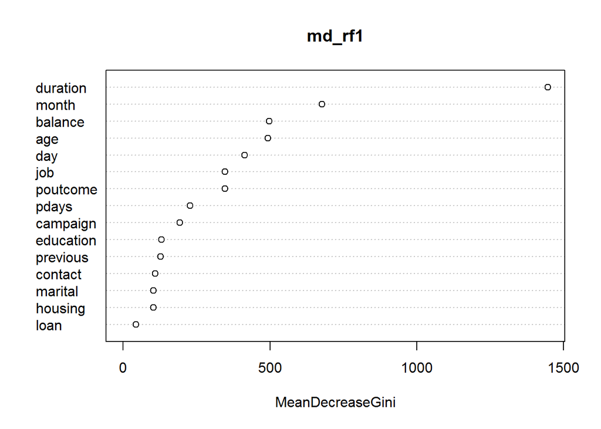

```r
varImpPlot(md_rf1,type=2)
```

We may also see that the feature “duration”is the most important one. Therefore, while we’re considering which features to be applied to our random forest model, we can firstly build a basic random forest model. Then, **varImpPlot** function can help us identify which features have greater influence to our model. This step can help optimize the model.

### C. Comparisons

#### Compare random forest with logistic model within different packages

[output not shown]

#### We can see once we increase the amount of trees, in most cases, the accuracy may go up. However, it may take a bit longer time to train the models.

#### If we control our method to random forest, we can clearly see the XGBoost package can efficiently train our model (although it’s accuracy is worse that other two packages)

#### If we compare different methods with different packages, we can also see that, in general, random forest model performs better accuracy than logistic model.

### This is the end of the weekly report. Thank you for your reading! :)